# Case_Study_2_Code

Brian Gaither, Sean Mcwhirter, Andrew Mejia, Sabrina Purvis

2021-01-17 14:08:51

# The following code has been adopted from the text book

# NOLAN, D. (2017). DATA SCIENCE IN R: A case studies approach to computational reasoning and problem solving. Place of publication not identified: CRC Press.

# https://github.com/ngupta23/ds7333_qtw/tree/master/case_study_1/submission_Kannan_Moro_Gupta/code

# and class room starter code

```r
library(tidyverse)
library(magrittr)
```

```r
library(plotly)
library(DT)
library(flexclust)
```

## Clustering Distance and Mac Addresses of interest

## Since we are running this experiment over multiple loops, variable macAddressInt will be changed to include :c0 and :cd

```r
#Clustering Distance methods
Cluster_Dist = 'Manhattan'
errMethod = ifelse(Cluster_Dist == 'Manhattan','MAE','RMSE')

#inverse of distance PG 42
weightFormula = function(x){ 1/(x)}

# Required MAC Addresses of interest
macAddressInt = c(
  #'00:0f:a3:39:e1:c0', #Exclude from list
  '00:0f:a3:39:dd:cd',
  '00:14:bf:b1:97:8a',
  '00:14:bf:3b:c7:c6',
  '00:14:bf:b1:97:90',
  '00:14:bf:b1:97:8d',
  '00:14:bf:b1:97:81'
)
```

## This is the directory of the data f_paths passed out during class.

```r
offline_f_path = "/home/andrew/Desktop/DS7333/offline.final.trace.txt"
#offline_f_path = "C:/Users/BGaither/OneDrive - McAfee/Other/school/SMU/Courses/Spring 2021/Quantifying The World/Case Study 2/Data/offline.final.trace.txt"
online_f_path = "/home/andrew/Desktop/DS7333/online.final.trace.txt"
#online_f_path = "C:/Users/BGaither/OneDrive - McAfee/Other/school/SMU/Courses/Spring 2021/Quantifying The World/Case Study 2/Data/online.final.trace.txt"
```

# The following function are from the starter code to process the raw data

```r
# Create a function to parse the data based on the tokens passed
processLine = function(x){
  # Split the line on: ';', '=' and ','
  tokens = strsplit(x, "[;=,]")[[1]]

  # The hand held device
  # is in the 1st 10 tokens (refer to text on page 9)
  # We change our function to return NULL if the tokens vector only has 10 elements (refer to page 11) as in the case of a missing signal
  if (length(tokens) == 10) {
    return(NULL)
  }

  # The tokens after the 10th one represent the signal strength at the access points (page 9).
  # Split the tokens into individual attributes:  MAC address, Signal, Channel and Device Type
  # Device mode type 3 is important  page 6 and 7 table 1.1
  # Device mode type 1 is the adhoc device
  # save this into tmp as a matrix with tokens 1:10
  tmp = matrix(data = tokens[ - (1:10) ], ncol = 4, byrow = TRUE)

  #We can think of these as rows in a 4-column matrix or data frame giving the MAC address,signal, channel, and device type,
  #So let’s unravel these and build a matrix from the values.
  #Then we can bind these columns with the values from the first 10 entries.
  cbind(matrix(tokens[c(2, 4, 6:8, 10)], nrow(tmp), 6, byrow = TRUE), tmp)
}
```

```r
roundOrientation = function(angles) {
  refs = seq(0, by = 45, length = 9)
  q = sapply(angles, function(o) which.min(abs(o - refs)))
    c(refs[1:8], 0)[q]
  }
```

# Page 19 exercise to create readData() function

```r
# The purpose of this function is  to read the data f_path as described in page 19,  transform the parsed f_path to the dataframe for analysis
# f_path is the name of offline and online data to be read in
# macAddressInt The list of Mac addresses of interest, initialize at Null as a placeholder
# Return A dataframe df


readData = function(f_path, macAddressInt=NULL){
  # Read in the raw "offline" text from f_path
  txt = readLines(f_path)

#Process and input raw data

  # Parse the f_path lines and not include '#'
  lines = txt[substr(txt, 1, 1) != "#" ]

  #apply processesline function to read lines and save as a temporary variable
  tmp = lapply(lines, processLine)

  # Convert the tmp variable to a data frame df through binding rows
  df = as.data.frame(do.call("rbind", tmp), stringsAsFactors = FALSE)

# Begin process to construction offline dataframe

  # Assign column names to the offline dataframe from time, scanMac, posX, posY, posZ, orientation angle, mac, signal, channel and type
  names(df) = c(
    "time", "scanMac", "posX", "posY", "posZ",
    "orientation", "mac", "signal",
    "channel", "type"
  )

  #Cast the string variables from the data to numeric variables

  numericVars = c("time", "posX", "posY", "posZ", "orientation", "signal")
  df[numericVars] = lapply(df[numericVars], as.numeric)

  # We will only keep required device types and remove the adhoc device (mode 1) refer to page 7 table 1.1
  df = df[df$type != 1, ]

  # We are only interested in the mac addresses of interest
  # We will filter the data frame to only include macs of interest and return the attributes of the macs of interest
  df = df[df$mac %in% macAddressInt, ]


  # Drop the scanMac and posZ attributes

  #https://stackoverflow.com/questions/4605206/drop-data-frame-columns-by-name
  #Max Ghenis Answer

  df = within(df, rm("scanMac", "posZ"))

  # Apply round orientation function to df orientation to round angles
  df$angle = roundOrientation(df$orientation)

  # Create posXY column
  df$posXY = paste(df$posX, df$posY, sep = "-")

  return(df)
}
```

# Offline data

```r
numMacs = length(macAddressInt)
numMacs
```

```
## [1] 6
```

```r
offline = readData(f_path = offline_f_path, macAddressInt = macAddressInt)
dim(offline)
```

```
## [1] 769089     10
```

```r
length(unique(offline$posXY))
```

```
## [1] 166
```

# Online Data

```r
online = readData(f_path = online_f_path, macAddressInt = macAddressInt)
dim(online)
```

```
## [1] 34815    10
```

```r
length(unique(online$posXY))
```

```
## [1] 60
```

# Function (Reshape) page 33

```r
# Unlike text example, we will initialize sampleAngle as false, so we do not select a sample of angles, if True, the ans x will take a random sample from the 45 degree angles increments (pg 38). This sampling technique was borrowed from page 38.

reshapeSS = function(data, varSignal = "signal", keepVars = c("posXY", "posX", "posY"), sampleAngle = FALSE) {
  refs = seq(0, by = 45, length = 8)
  byLocation =
  with(
    data,
    by(
      data,
      list(posXY),
      function(x) {
        #page 38 to select one angle at random for each location
        if (sampleAngle) x = x[x$angle == sample(refs, size = 1), ]
        ans = x[1, keepVars]
        #page 38, we impute from the the mean the missing values
        avgSS = tapply(x[ , varSignal ], x$mac, mean)
        y = matrix(avgSS, nrow = 1, ncol = numMacs,
        dimnames = list(ans$posXY, names(avgSS)))
        cbind(ans, y)
      }
    )
  )
  newDataSS = do.call("rbind", byLocation)
  return(newDataSS)
}
```

# Reshape Test Data Keeping only the flowing variables, “posXY”, “posX”,“posY”, “orientation”, “angle”

```r
keepVars = c("posXY", "posX","posY", "orientation", "angle")
onlineSummary = reshapeSS(data = online, varSignal = "signal", keepVars = keepVars)
head(onlineSummary,10)
```

```
##                 posXY posX  posY orientation angle 00:0f:a3:39:dd:cd
## 0-0.05         0-0.05 0.00  0.05       130.5   135         -63.20721
## 0.15-9.42   0.15-9.42 0.15  9.42       112.3    90         -66.11712
## 0.31-11.09 0.31-11.09 0.31 11.09       230.1   225         -67.05405
## 0.47-8.2     0.47-8.2 0.47  8.20         5.8     0         -74.15315
## 0.78-10.94 0.78-10.94 0.78 10.94       348.3     0         -71.40367
## 0.93-11.69 0.93-11.69 0.93 11.69       158.3   180         -69.99074
## 1.08-12.19 1.08-12.19 1.08 12.19       229.1   225         -73.43750
## 1.24-3.93   1.24-3.93 1.24  3.93       261.5   270         -71.11009
## 1.39-6.61   1.39-6.61 1.39  6.61       114.1   135         -59.75676
## 1.52-9.32   1.52-9.32 1.52  9.32         7.0     0         -65.38318
##            00:14:bf:3b:c7:c6 00:14:bf:b1:97:81 00:14:bf:b1:97:8a
## 0-0.05             -62.94898         -61.81395         -40.06897
## 0.15-9.42          -73.96190         -72.70103         -47.81308
## 0.31-11.09         -70.08247         -70.09890         -54.08824
## 0.47-8.2           -64.25806         -72.59770         -45.65289
## 0.78-10.94         -66.96000         -66.80952         -48.41379
## 0.93-11.69         -70.44340         -70.58025         -43.66346
## 1.08-12.19         -69.20192         -67.92553         -52.00820
## 1.24-3.93          -69.62745         -59.76136         -38.91753
## 1.39-6.61          -62.23913         -64.56627         -48.92381
## 1.52-9.32          -63.35922         -67.48913         -50.04167
##            00:14:bf:b1:97:8d 00:14:bf:b1:97:90
## 0-0.05             -63.04301         -55.23333
## 0.15-9.42          -69.45455         -46.88000
## 0.31-11.09         -69.13158         -53.88660
## 0.47-8.2           -60.79747         -49.58000
## 0.78-10.94         -65.00000         -54.84694
## 0.93-11.69         -65.59302         -47.27083
## 1.08-12.19         -71.58696         -51.66667
## 1.24-3.93          -71.66667         -53.23333
## 1.39-6.61          -60.79798         -50.49057
## 1.52-9.32          -65.10345         -49.38542
```

# Function Select Train Data page 33 - 34

```r
# Select Train Data selects the appropriate observations (based on test data orientation) from the original tall form data
# and reformats for training the KNN algorithm
# angleNewObs Angle  of the new observation
# Train_data Original format of offlineSummary (Tall form) if signals
# m the angles to include from signals
# Return a dataframe for training KNN algorithm

selectTrain = function(angleNewObs, train_data, m){

#Apply angle rounding

  nearestAngle = roundOrientation(angles = angleNewObs)


# if angle has a remainder, of 1 round down to the nearest 45 degree angle else round up.
  if (m %% 2 == 1) {
    angles = seq(-45 * (m - 1) /2, 45 * (m - 1) /2, length = m)
  } else {
    m = m + 1
    angles = seq(-45 * (m - 1) /2, 45 * (m - 1) /2, length = m)
    if (sign(angleNewObs - nearestAngle) > -1)
      angles = angles[ -1 ]
    else
      angles = angles[ -m ]
  }

  angles = angles + nearestAngle
  angles[angles < 0] = angles[ angles < 0 ] + 360
  angles[angles > 360] = angles[ angles > 360 ] - 360

  # Subset only those angles from original data (tall-skinny)
  train_data_subset = train_data[train_data$angle %in% angles, ]

  # Convert to Wide and average the data for the same positions
  train_data_subset = reshapeSS(data = train_data_subset, varSignal = "signal")

  return(train_data_subset)
}
```

#Calculate Nearest Neighboors # Page 35 and 36

```r
# Computes the distance of the new signal (single observation) to each observation in the training dataset based on Euclidian or Manhattan distance
# newSignal is the signal value from the validation data set observation
# trainSubset the training data to be passed
# Weighted default is FALSE to include weighted formula if TRUE else if False, weighted will just repeat weight of 1 for the distances
# Returns dataframe containing same number of rows as that in the training data.
# To calculate distance
#https://machinelearningmastery.com/distance-measures-for-machine-learning/#:~:text=Manhattan%20distance%20is%20calculated%20as,differences%20between%20the%20two%20vectors.&text=The%20Manhattan%20distance%20is%20related,and%20mean%20absolute%20error%20metric.


findNN = function(newSignal, trainSubset, weighted=FALSE, method = Cluster_Dist) {
  #Instead of fixing the range of the columns of the vector from 4 to 9, we will use numMacs - 1 as the column indexer
  diffs = apply(trainSubset[ , 4:(4+numMacs-1)], 1, function(x) x - newSignal)
  # The following code is credited to https://github.com/ngupta23/ds7333_qtw/tree/master/case_study_1/submission_Kannan_Moro_Gupta/code
  #If Euclidian distance, distance is the Mean Square Error
  if(method=='Euclidian')  dists = apply(diffs, 2, function(x) sqrt(sum(x^2)) )
  #If Manhattan distance is the sum of the absolute error of the measurement
  if(method=='Manhattan')  dists = apply(diffs, 2, function(x) sum(abs(x)) )
  #Sort the distances in ascending order
  closest = order(dists)
  #only return closest distances
  ordered_dist = dists[closest]
  #When true, return the ordered ascending closest neighbors with weight
  if(weighted == TRUE){
    weight = weightFormula(ordered_dist)
  }
  #If false, return all equal weights of 1
  if(weighted == FALSE){
    weight = rep(1, length(dists))
  }
  return(cbind(trainSubset[closest, 1:3], ordered_dist, weight))
}
```

#Page 35 # The following code is adopted and credited to https://github.com/ngupta23/ds7333_qtw/tree/master/case_study_1/submission_Kannan_Moro_Gupta/code

```r
# XY Prediction for a single value of k neighboors
# newSignals the signal values for the validation data for each observation
# newAngles the orientation of the validation data for each observation
# trainData the training data to be used
# numAngles number of closest reference angles to include in the data
# k  predicton for num neighbors = k
# weighted default FALSE, include weighted distance
# Returns dataframe with n rows  = number of (validation) observations and n columns = 2
# Each row is the  prediction of the mean X and Y values for that observation
predXY = function(newSignals, newAngles, trainData, numAngles = 1, k = 3, weighted=FALSE){
  closeXY = list(length = nrow(newSignals))
  for (i in 1:nrow(newSignals)) {
    trainSS = selectTrain(newAngles[i], trainData, m = numAngles)
    closeXY[[i]] = findNN(
      newSignal = as.numeric(newSignals[i, ]),
      trainSubset = trainSS,
      weighted = weighted
    )
  }
  #PG 40, not use CUMSUM function, use weighted mean
  # Returns the k-means observation based on weights for a single observation
  # df Dataframe containing 5 columns , XY, X, Y, Distance, Inverse Distance
  # k sorted nearest neighboors list to calculate weight
  # A pair of XY weighted means values for k number of neighbors

  #Calculate the weigheted mean
  #https://www.mathsisfun.com/data/weighted-mean.html
  # The following code is adopted and credited to https://github.com/ngupta23/ds7333_qtw/tree/master/case_study_1/submission_Kannan_Moro_Gupta/code
  k_means_single_obs = function(df, k){
    weights = df[1:k, 5]
    weighted_x = weighted.mean(df[1:k,2],weights)
    weighted_y = weighted.mean(df[1:k,3],weights)

    return(c(weighted_x, weighted_y))
  }

  estXY = lapply(closeXY, k_means_single_obs, k)
  estXY = do.call("rbind", estXY)
  return(estXY)
}
```

```r
calcError = function(estXY, actualXY, method = Cluster_Dist){
  if('numeric' %in% class(estXY)) rows = 1 else rows = nrow(estXY)
  if(method == 'Euclidean')  error = sqrt(sum(rowSums((estXY - actualXY)^2)))/rows
  if(method == 'Manhattan')  error = sum(rowSums(abs(estXY - actualXY)))/rows
  return(error)
}
```

# K-Fold

## Setup

#Page 37

```r
#subset size
v = 11
permuteLocs = sample(unique(offline$posXY))
permuteLocs = matrix(permuteLocs, ncol = v, nrow = floor(length(permuteLocs)/v))
permuteLocs
```

```
##       [,1]   [,2]   [,3]   [,4]   [,5]   [,6]   [,7]   [,8]   [,9]   [,10]
##  [1,] "25-4" "23-3" "30-3" "1-5"  "21-4" "2-0"  "22-4" "13-6" "21-3" "27-7"
##  [2,] "16-3" "1-10" "0-2"  "20-3" "1-1"  "1-12" "24-6" "16-7" "2-8"  "9-4"
##  [3,] "24-5" "9-7"  "25-3" "2-5"  "13-7" "27-8" "2-10" "12-3" "23-8" "21-5"
##  [4,] "9-8"  "16-8" "19-7" "23-5" "29-7" "26-7" "31-3" "12-6" "31-7" "4-7"
##  [5,] "12-5" "23-4" "32-6" "11-4" "1-9"  "1-11" "0-3"  "0-0"  "12-8" "2-6"
##  [6,] "14-8" "9-3"  "30-8" "26-6" "0-9"  "23-6" "15-7" "3-3"  "28-7" "32-3"
##  [7,] "14-7" "17-7" "2-3"  "6-8"  "7-3"  "8-8"  "3-8"  "12-7" "2-4"  "12-4"
##  [8,] "4-3"  "6-3"  "24-7" "17-8" "5-7"  "1-13" "0-7"  "24-4" "5-8"  "21-7"
##  [9,] "27-3" "29-8" "10-5" "1-8"  "21-6" "4-8"  "30-7" "19-3" "0-13" "22-5"
## [10,] "11-7" "21-8" "14-3" "3-7"  "2-9"  "11-8" "0-10" "26-5" "33-3" "0-8"
## [11,] "13-3" "28-8" "23-7" "2-12" "28-3" "22-3" "0-12" "0-11" "32-8" "31-8"
## [12,] "15-3" "18-7" "18-3" "2-1"  "1-7"  "10-8" "1-4"  "33-4" "26-4" "19-8"
## [13,] "32-5" "11-6" "13-8" "13-5" "7-8"  "1-0"  "10-4" "26-3" "22-7" "5-3"
## [14,] "26-8" "24-3" "8-7"  "32-7" "22-8" "6-7"  "10-6" "13-4" "0-4"  "2-11"
```

[output cut: 17 more lines]

The following code will investigate our three MAC scenarios. 1) Drop 00:0f:a3:39:e1:c0 and keep the rest, 2) Drop 00:0f:a3:39:dd:cd and keep the rest, and 3) Keep all MAC addresses. We’ll also evaluate whether looking for up to 3 angles for prediction purposes aids in finding a better prediction.

```r
#Iterate through the MAC scenarios and generate the elbow plot while also checking for the best number of angles
set.seed(959)
K=20
noAngles = 3
v == 11
```

```
## [1] TRUE
```

```r
macPerms = c("Drop: 00:0f:a3:39:e1:c0","Drop: 00:0f:a3:39:dd:cd","Keep All")
# Required MAC Addresses of interest, here we include all mac addresses
macAddressInt = c(
  '00:0f:a3:39:e1:c0', #Exclude from list
  '00:0f:a3:39:dd:cd',
  '00:14:bf:b1:97:8a',
  '00:14:bf:3b:c7:c6',
  '00:14:bf:b1:97:90',
  '00:14:bf:b1:97:8d',
  '00:14:bf:b1:97:81'
)
numMacs = length(macAddressInt)
#read the data with all mac addresses, we'll subset to remove specific mac addresses later
offline = readData(f_path = offline_f_path, macAddressInt = macAddressInt)
online = readData(f_path = online_f_path, macAddressInt = macAddressInt)

#set mac addresses of interest
macAddressIteration = macAddressInt
numMacs = length(macAddressIteration)
#used in the onlineFold creation
keepVars = c("posXY", "posX","posY", "orientation", "angle")

#create dataframe to hold results with errors
dfResults <- data.frame("Scenario"=factor(),"AngleCount"=integer(),"K_value"=integer(),"Error"=double())

for (f in 1:length(macPerms)){
  #in this loop we need to make sure our data only consists of the mac addresses we care about
  if (f < 3){
    #the first two scenarios involve dropping a mac address, this logic handles that
    print(paste0("Current Mac Scenario: ", f))
    macAddressIteration = macAddressInt[-f]
    numMacs = length(macAddressIteration)
  }else{
    print(paste0("Current Mac Scenario: ", f))
    macAddressIteration = macAddressInt
    numMacs = length(macAddressIteration)
  }
  offlineIt = subset(offline, mac %in% macAddressIteration)
  onlineIt = subset(online, mac %in% macAddressIteration)
  onlineCVSummary = reshapeSS(offlineIt, keepVars = keepVars, sampleAngle = TRUE)
  for (a in 1:noAngles){
    print(paste0("     Current number of angles: ", a))
    for (j in 1:v){
      #create folds for cross validation
      print(paste0("          Current crossfold: ", j))
      onlineFold = subset(onlineCVSummary, posXY %in% permuteLocs[,j])
      if(f==3){print(paste0("          onlinefold created: ", j))}
      offlineFold = subset(offlineIt, posXY %in% permuteLocs[,-j])
      if(f==3){print(paste0("          offlinefold created: ", j))}
      actualFold = onlineFold[, c("posX","posY")]
      if(f==3){print(paste0("          actualfold created: ", j))}

      for (i in 1:K){
          if(f<3){
            estFold = predXY(newSignals = onlineFold[, 6:11], newAngles = onlineFold[, 4], offlineFold, numAngles = a, k = i)
          }else{
            estFold = predXY(newSignals = onlineFold[, 6:12], newAngles = onlineFold[, 4], offlineFold, numAngles = a, k = i)
          }
          myError = calcError(estFold, actualFold)
          print(paste0("               estimation and error calculated: ", i))
          if((f==1)&(a==1)&(j==1)&(i==1)){
            print(paste0("                    first time loading results K: ", i))
            dfResults <- data.frame("Scenario"=macPerms[f], "AngleCount"=a, "K_value"=i,"Error"=myError)
          }else{
            print(paste0("                    subsequent times loading results K: ", i))
            dfRow <- data.frame("Scenario"=macPerms[f], "AngleCount"=a, "K_value"=i,"Error"=myError)
            dfResults <- rbind(dfResults, dfRow)
          }

        }

      }

    }
}
```

[output not shown]

[output cut: 4155 more lines]

```r
#write.csv(dfResults,"C:/Users/BGaither/OneDrive - McAfee/Other/school/SMU/Courses/Spring 2021/Quantifying The World/Case Study 2/Data/cv_results.csv", row.names = FALSE)
write.csv(dfResults,"/home/andrew/Desktop/DS7333/cv_results.csv", row.names = FALSE)
dfResults
```

```
##                     Scenario AngleCount K_value    Error
## 1    Drop: 00:0f:a3:39:e1:c0          1       1 2.933333
## 2    Drop: 00:0f:a3:39:e1:c0          1       2 2.533333
## 3    Drop: 00:0f:a3:39:e1:c0          1       3 2.444444
## 4    Drop: 00:0f:a3:39:e1:c0          1       4 2.533333
## 5    Drop: 00:0f:a3:39:e1:c0          1       5 2.293333
## 6    Drop: 00:0f:a3:39:e1:c0          1       6 2.555556
## 7    Drop: 00:0f:a3:39:e1:c0          1       7 2.590476
## 8    Drop: 00:0f:a3:39:e1:c0          1       8 2.533333
## 9    Drop: 00:0f:a3:39:e1:c0          1       9 2.548148
## 10   Drop: 00:0f:a3:39:e1:c0          1      10 2.600000
## 11   Drop: 00:0f:a3:39:e1:c0          1      11 2.654545
## 12   Drop: 00:0f:a3:39:e1:c0          1      12 2.694444
## 13   Drop: 00:0f:a3:39:e1:c0          1      13 2.625641
## 14   Drop: 00:0f:a3:39:e1:c0          1      14 2.709524
```

[output cut: 1966 more lines]

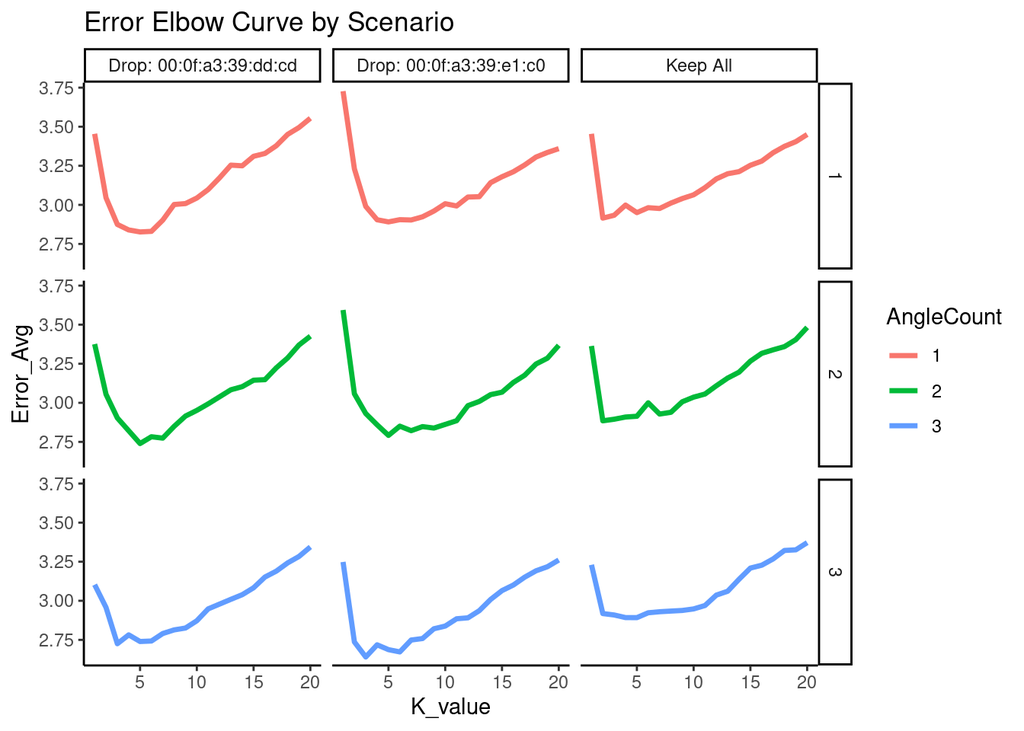

```r
library(ggplot2)
#dfResults = read.csv("C:/Users/BGaither/OneDrive - McAfee/Other/school/SMU/Courses/Spring 2021/Quantifying The World/Case Study 2/Data/cv_results.csv",header = TRUE)
#dfResGroup = dfResults %>% filter(AngleCount==3) %>% group_by(Scenario, AngleCount, K_value) %>% summarize(Error_Avg = mean(Error))
dfResults$AngleCount <- as.factor(dfResults$AngleCount)
dfResGroup = dfResults %>% group_by(Scenario, AngleCount, K_value) %>% summarize(Error_Avg = mean(Error))
#Individual aes() …. an aesthetic for each layer
ggplot(data = dfResGroup) +
geom_line(mapping = aes(x=K_value, y=Error_Avg, color=AngleCount), size=1.2) + facet_grid(rows=vars(AngleCount), cols=vars(Scenario)) + theme_classic() + labs(title="Error Elbow Curve by Scenario")
```

```r
dfResultsGroupMin = dfResGroup %>% group_by(Scenario, AngleCount) %>% summarize(Error_Avg = min(Error_Avg))
dfOptK = merge(dfResGroup, dfResultsGroupMin, by=c("Scenario", "AngleCount", "Error_Avg"))
dfOptK
```

```
##                  Scenario AngleCount Error_Avg K_value
## 1 Drop: 00:0f:a3:39:dd:cd          1  2.826667       5
## 2 Drop: 00:0f:a3:39:dd:cd          2  2.739394       5
## 3 Drop: 00:0f:a3:39:dd:cd          3  2.725253       3
## 4 Drop: 00:0f:a3:39:e1:c0          1  2.890909       5
## 5 Drop: 00:0f:a3:39:e1:c0          2  2.791515       5
## 6 Drop: 00:0f:a3:39:e1:c0          3  2.640404       3
## 7                Keep All          1  2.915152       2
## 8                Keep All          2  2.884848       2
## 9                Keep All          3  2.892121       5
```

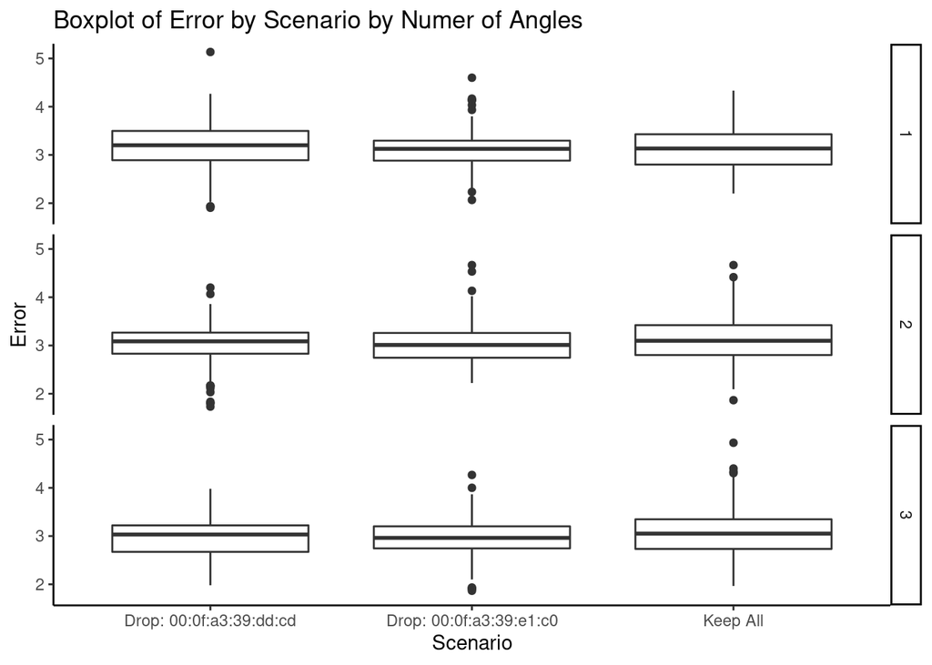

```r
ggplot(dfResults) + geom_boxplot(mapping = aes(x=Scenario, y=Error)) + facet_grid(rows=vars(AngleCount)) + theme_classic() + labs(title="Boxplot of Error by Scenario by Numer of Angles")
```

From the boxplot, we can see that there are some extreme error values when dropping 00:0f:a3:39:dd:cd. Let’s check dropping 00:0f:a3:39:e1:c0 and do an end to end analysis.

```r
macAddressInt = c(
  #'00:0f:a3:39:e1:c0', #Exclude from list
  '00:0f:a3:39:dd:cd',
  '00:14:bf:b1:97:8a',
  '00:14:bf:3b:c7:c6',
  '00:14:bf:b1:97:90',
  '00:14:bf:b1:97:8d',
  '00:14:bf:b1:97:81'
)
numMacs = length(macAddressInt)

offlineIt = subset(offline, mac %in% macAddressInt)
onlineIt = subset(online, mac %in% macAddressInt)
keepVars = c("posXY", "posX","posY", "orientation", "angle")
onlineCVSummary = reshapeSS(offlineIt, keepVars = keepVars, sampleAngle = TRUE)

i=6
noAngles = 1

actualLocation = onlineCVSummary[ , c("posX", "posY")]
estLocation = predXY(newSignals = onlineCVSummary[ , 6:11], newAngles = onlineCVSummary[ , 4], offlineIt, numAngles = noAngles, k = i)
locError =  calcError(estLocation, actualLocation)

locError
```

```
## [1] 2.24498
```

Let’s check the actual locations and then we’ll compare the predicted locations for spot check.

```r
actualLocation
```

```
##      posX posY
## 0-0     0    0
## 0-1     0    1
## 0-10    0   10
## 0-11    0   11
## 0-12    0   12
## 0-13    0   13
## 0-2     0    2
## 0-3     0    3
## 0-4     0    4
## 0-7     0    7
## 0-8     0    8
## 0-9     0    9
## 1-0     1    0
## 1-1     1    1
## 1-10    1   10
## 1-11    1   11
## 1-12    1   12
## 1-13    1   13
## 1-2     1    2
## 1-3     1    3
## 1-4     1    4
## 1-5     1    5
## 1-6     1    6
## 1-7     1    7
## 1-8     1    8
## 1-9     1    9
## 10-3   10    3
## 10-4   10    4
## 10-5   10    5
## 10-6   10    6
## 10-7   10    7
## 10-8   10    8
## 11-3   11    3
## 11-4   11    4
## 11-5   11    5
## 11-6   11    6
## 11-7   11    7
## 11-8   11    8
## 12-3   12    3
```

[output cut: 112 more lines]

```
## 5-7     5    7
## 5-8     5    8
## 6-3     6    3
## 6-7     6    7
## 6-8     6    8
## 7-3     7    3
## 7-7     7    7
## 7-8     7    8
## 8-3     8    3
## 8-7     8    7
## 8-8     8    8
## 9-3     9    3
## 9-4     9    4
## 9-7     9    7
## 9-8     9    8
```

Below we have the predicted locations, we do see that most predictions are in the ball park, however it’s not perfect.

```r
dfEstLoc = as.data.frame(estLocation)
names(dfEstLoc)[names(dfEstLoc)=="V1"] <-"posX"
names(dfEstLoc)[names(dfEstLoc)=="V2"] <-"posY"
dfEstLoc
```

```
##              posX      posY
## length  0.1666667  5.000000
## X       1.0000000  1.500000
## X.1     0.5000000  9.333333
## X.2     0.5000000  8.166667
## X.3     0.8333333 10.500000
## X.4     0.5000000 11.666667
## X.5     0.8333333  3.333333
## X.6     1.0000000  3.500000
## X.7     0.8333333  2.500000
## X.8     1.5000000  7.333333
## X.9     1.1666667  4.833333
## X.10    1.0000000  7.000000
## X.11    0.8333333  1.166667
## X.12    1.5000000  6.000000
## X.13    0.6666667  5.333333
## X.14    1.1666667 10.666667
## X.15    1.0000000  9.833333
## X.16    1.1666667 11.833333
## X.17    0.8333333  2.500000
## X.18    0.8333333  4.500000
## X.19    1.8333333  4.166667
## X.20    1.0000000  4.166667
## X.21    0.8333333  7.500000
## X.22    1.1666667  7.333333
## X.23    1.1666667  7.333333
## X.24    1.1666667  6.500000
## X.25   10.1666667  3.333333
## X.26   13.6666667  5.666667
## X.27   11.5000000  5.500000
## X.28    9.5000000  6.000000
## X.29   11.8333333  6.666667
## X.30   10.0000000  7.000000
## X.31   11.0000000  3.666667
## X.32    9.8333333  3.500000
## X.33   10.8333333  4.833333
## X.34    9.5000000  5.000000
## X.35   11.5000000  7.500000
## X.36   12.5000000  7.166667
## X.37   11.5000000  4.000000
```

[output cut: 112 more lines]

```
## X.150   8.5000000  7.000000
## X.151   5.3333333  6.833333
## X.152   5.5000000  4.333333
## X.153   8.0000000  6.500000
## X.154   7.3333333  5.833333
## X.155   6.8333333  5.500000
## X.156   6.8333333  6.166667
## X.157   7.8333333  7.000000
## X.158   9.1666667  3.333333
## X.159  10.0000000  7.500000
## X.160   8.3333333  7.500000
## X.161   7.1666667  4.000000
## X.162   9.6666667  6.000000
## X.163  10.3333333  7.666667
## X.164   9.0000000  7.666667
```

Let’s take a look at what the predicted versus actual locations look like plotted out.

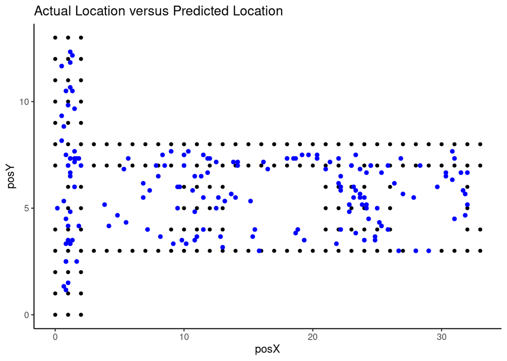

```r
ggplot(actualLocation,aes(posX,posY)) +
geom_point(size=1.2) + geom_point(data=dfEstLoc, color="blue")+ theme_classic() + labs(title="Actual Location versus Predicted Location")
```

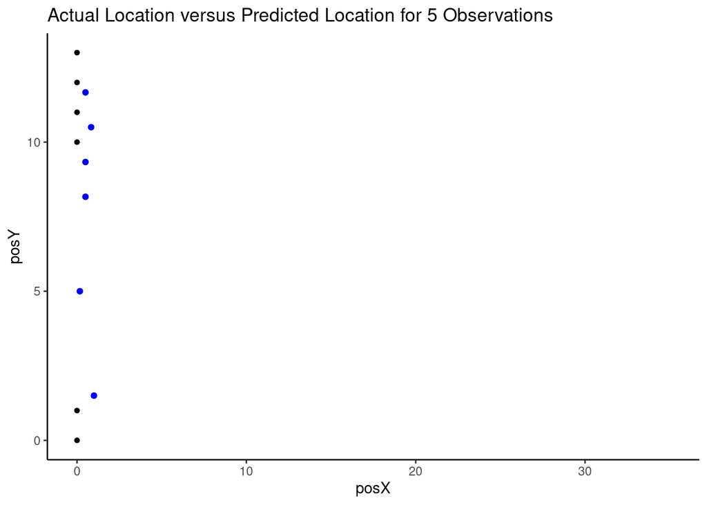

```r
ggplot(head(actualLocation),aes(posX,posY)) +
geom_point(size=1.2) + geom_point(data=head(dfEstLoc), color="blue")+ theme_classic() + labs(title="Actual Location versus Predicted Location for 5 Observations")+ xlim(0, 35)
```

```r
macAddressInt = c(
  '00:0f:a3:39:e1:c0', #Exclude from list
  '00:0f:a3:39:dd:cd',
  '00:14:bf:b1:97:8a',
  '00:14:bf:3b:c7:c6',
  '00:14:bf:b1:97:90',
  '00:14:bf:b1:97:8d',
  '00:14:bf:b1:97:81'
)
numMacs = length(macAddressInt)

offlineIt = subset(offline, mac %in% macAddressInt)
onlineIt = subset(online, mac %in% macAddressInt)
keepVars = c("posXY", "posX","posY", "orientation", "angle")
onlineCVSummary = reshapeSS(offlineIt, keepVars = keepVars, sampleAngle = TRUE)

i=6
noAngles = 1

actualLocation = onlineCVSummary[ , c("posX", "posY")]
estLocation = predXY(newSignals = onlineCVSummary[ , 6:12], newAngles = onlineCVSummary[ , 4], offlineIt, numAngles = noAngles, k = i)
locError =  calcError(estLocation, actualLocation)

locError
```

```
## [1] 2.337349
```

Let’s check the actual locations and then we’ll compare the predicted locations for spot check.

```r
actualLocation
```

```
##      posX posY
## 0-0     0    0
## 0-1     0    1
## 0-10    0   10
## 0-11    0   11
## 0-12    0   12
## 0-13    0   13
## 0-2     0    2
## 0-3     0    3
## 0-4     0    4
## 0-7     0    7
## 0-8     0    8
## 0-9     0    9
## 1-0     1    0
## 1-1     1    1
## 1-10    1   10
## 1-11    1   11
## 1-12    1   12
## 1-13    1   13
## 1-2     1    2
## 1-3     1    3
## 1-4     1    4
## 1-5     1    5
## 1-6     1    6
## 1-7     1    7
## 1-8     1    8
## 1-9     1    9
## 10-3   10    3
## 10-4   10    4
## 10-5   10    5
## 10-6   10    6
## 10-7   10    7
## 10-8   10    8
## 11-3   11    3
## 11-4   11    4
## 11-5   11    5
## 11-6   11    6
## 11-7   11    7
## 11-8   11    8
## 12-3   12    3
```

[output cut: 112 more lines]

```
## 5-7     5    7
## 5-8     5    8
## 6-3     6    3
## 6-7     6    7
## 6-8     6    8
## 7-3     7    3
## 7-7     7    7
## 7-8     7    8
## 8-3     8    3
## 8-7     8    7
## 8-8     8    8
## 9-3     9    3
## 9-4     9    4
## 9-7     9    7
## 9-8     9    8
```

Below we have the predicted locations, we do see that most predictions are in the ball park, however it’s not perfect.

```r
dfEstLoc = as.data.frame(estLocation)
names(dfEstLoc)[names(dfEstLoc)=="V1"] <-"posX"
names(dfEstLoc)[names(dfEstLoc)=="V2"] <-"posY"
dfEstLoc
```

```
##              posX      posY
## length  0.8333333  2.000000
## X       1.0000000  3.000000
## X.1     1.0000000 10.166667
## X.2     0.8333333  7.666667
## X.3     0.3333333 10.166667
## X.4     0.3333333 11.166667
## X.5     0.8333333  5.000000
## X.6     1.0000000  3.000000
## X.7     0.6666667  2.833333
## X.8     1.3333333  6.500000
## X.9     1.0000000  6.666667
## X.10    1.0000000  6.166667
## X.11    1.0000000  1.500000
## X.12    0.8333333  3.833333
## X.13    1.0000000 10.333333
## X.14    1.1666667  9.833333
## X.15    0.8333333  9.166667
## X.16    1.3333333 12.333333
## X.17    0.8333333  2.333333
## X.18    0.8333333  2.666667
## X.19    0.6666667  5.500000
## X.20    0.8333333  1.333333
## X.21    1.6666667  5.833333
## X.22    1.5000000  6.500000
## X.23    0.6666667  6.333333
## X.24    0.6666667  9.833333
## X.25   10.1666667  3.333333
## X.26   10.8333333  4.666667
## X.27    9.8333333  5.000000
## X.28    9.6666667  5.666667
## X.29    9.5000000  7.166667
## X.30    8.0000000  7.500000
## X.31   10.3333333  3.333333
## X.32   11.6666667  5.000000
## X.33   11.5000000  6.166667
## X.34   12.6666667  6.000000
## X.35   10.5000000  7.000000
## X.36    9.0000000  7.500000
## X.37   11.1666667  3.666667
```

[output cut: 112 more lines]

```
## X.150   8.8333333  6.500000
## X.151   5.6666667  6.666667
## X.152   6.0000000  5.333333
## X.153   7.3333333  7.666667
## X.154   6.1666667  7.666667
## X.155   7.3333333  4.166667
## X.156   7.0000000  6.166667
## X.157  12.1666667  6.333333
## X.158  10.3333333  5.666667
## X.159   8.3333333  6.666667
## X.160   7.5000000  7.833333
## X.161  10.8333333  5.333333
## X.162   9.1666667  4.333333
## X.163   7.8333333  7.666667
## X.164   9.1666667  7.166667
```

Let’s take a look at what the predicted versus actual locations look like plotted out.

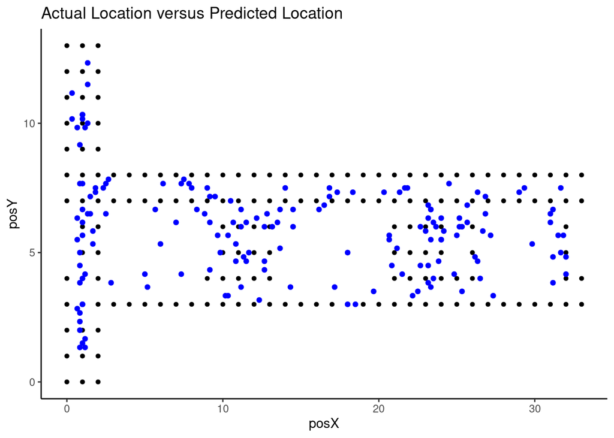

```r
ggplot(actualLocation,aes(posX,posY)) +
geom_point(size=1.2) + geom_point(data=dfEstLoc, color="blue")+ theme_classic() + labs(title="Actual Location versus Predicted Location")
```

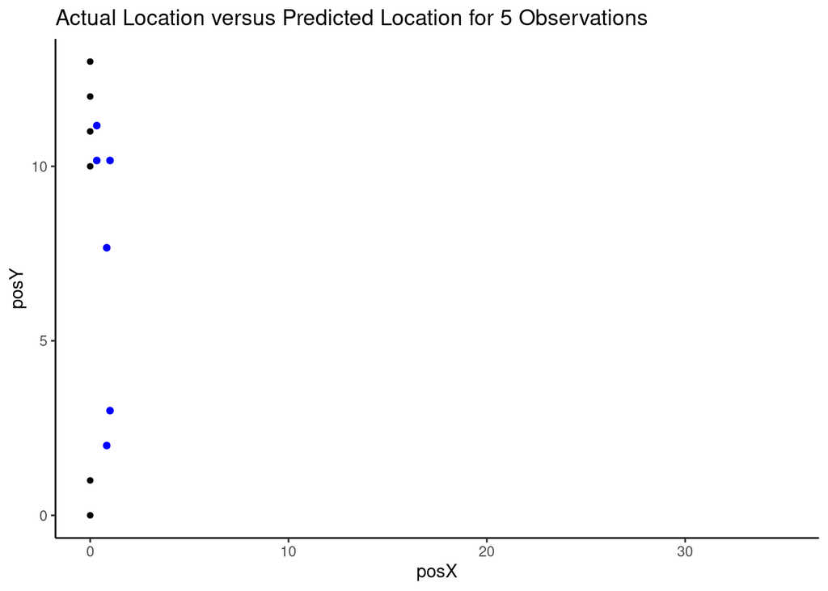

```r
ggplot(head(actualLocation),aes(posX,posY)) +
geom_point(size=1.2) + geom_point(data=head(dfEstLoc), color="blue")+ theme_classic() + labs(title="Actual Location versus Predicted Location for 5 Observations")+ xlim(0, 35)
```